# What are Geoethics?

> “not a limit to the freedom of action  
> but a new opportunity […] to contribute […]  
> the best way forward for society”

Peppoloni & Di Capua (2015)

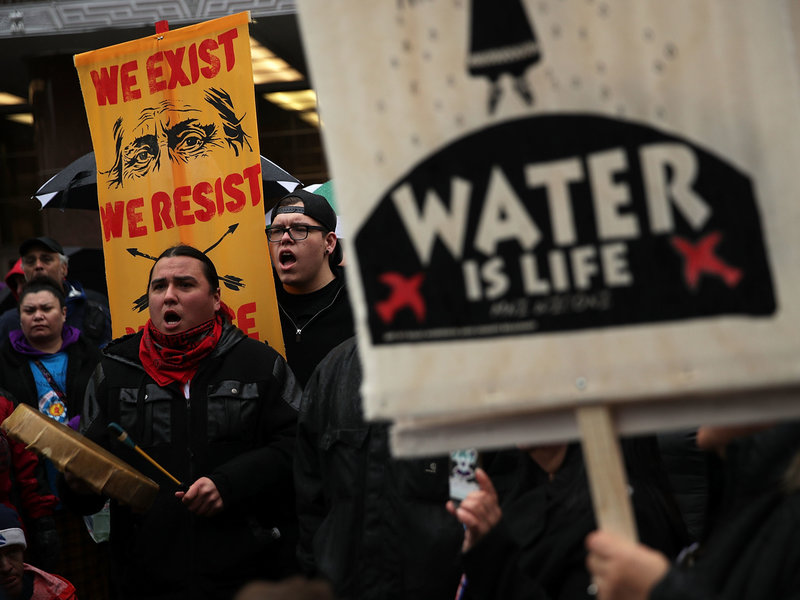

Members of the Standing Rock Sioux Tribe and its supporters,  
shown here during a demonstration in 2017,  
have opposed the Dakota Access Pipeline for years.  
Alex Wong/Getty Images

# Environmental Ethics

> the tradeoff between ethical concerns  
> and short-term economic benefits

* these both relate to what we *value* and how our values influence our actions

# Values

How do we value things?

| VALUE | DESCRIPTION |
| --- | --- |
| Use value | Something we use directly |
| Existence value | Knowing that something exists, even if we never experience it ourselves |
| Option value | Something we might use later |
| Aesthetic value | Something of beauty or emotional appeal |
| Scientific value | Something for research |
| Educational value | Something for teaching and learning |
| Cultural value | Something that sustains or defines a culture |

| **MORALS** | **ETHICS** |
| --- | --- |
| Personal principles with respect to right/wrong | Rules of conduct with respect to our culture |
| Individual | Societal |
| Internal | External |
| Something we “believe in” | Because society “says so” |
| Transcendental | Governed |

# Ethics

> the set of morals or beliefs of a given group that guide and clarify our actions

… so who is the group?

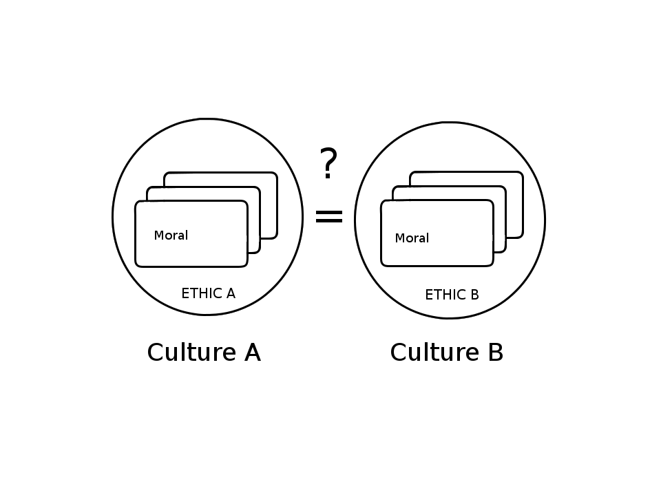

**Relativists**

each culture *should* be allowed their own ethics

(e.g., freedom of religion)

**Universalists**

there exist a single set of ethics that hold true for all cultures

(e.g. human rights/equality)

# From here things get tricky

# Back to geoethics

> “The well-being and survival of humankind depends on the Earth’s habitability and resources.”

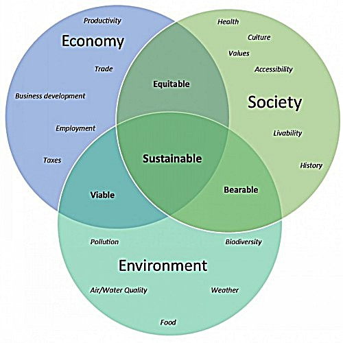

The “Triple Bottom Line” aka the Three P’s

# Geoethics are

> “the values which underpin appropriate behaviors and practices, wherever human activities interact with the Earth system”

IAPG

# Readings

- [Definition of Geoethics (IAPG)](http://www.geoethics.org/definition)
- [The Meaning of Geoethics, Peppoloni & Di Capua (2015)](http://www.geoethics.org/articles-geoethics#comp-ijx091vi)

# Task

Find an article online (news story, blog post, journal article, etc.), post a link to it in our discussion forum and write a few sentences discussing what is of value and what are the major ethical points of the article.

What is your opinion of the ethical concern?

# Further Readings

- [The Emerging Field of Geoethics, Bobrowsky et al. (2017)](http://www.geoethics.org/articles-geoethics#comp-jjfx3jvm)
- [International Association for Promoting Geoethics](http://www.geoethics.org/)